# PROBABILITY DENSITY ESTIMATION

13 Apr 2021 (*updated: 2021-04-13)*

## i. Week 12 Focus

- Students Practice on Ch. 11 content.
- Students receive and act on Ch.7 feedback.
- Read Prob Den. Est. Ch. 12.
- Discuss Prob Den. Est. Ch. 12.

## HW discussion

- 7.D. vary d,n to see strange pattern.
- 8.7 Use B >= 2000. Interpret a little more. What do these numbers mean? Is the bootstrap unbiased?
- 9.6 How to interpret jackknife plots?

## Any questions on Ch.11 HW?

- 11.1, 11.2 M-H practice and understanding.
- 11.5 MCMC in Bayesian inference (repeat the analysis on 2nd data set with uniform prior).
- 11.10 Gibbs with full conditionals available.
- 11.12 Convergence diagnostics
- 11.15 Change Point and HPDI.

## Today’s plan

1. Finish Ch.11 MCMC discussion in `20_ch11_MCMC2.Rmd`
   - Bayesian posterior M-H derivation
   - Gibbs sampler explained
   - `coda`
   - Modern MCMC / HMC
2. Discuss on Ch. 12 Problem Set to prime learning.
3. Discuss Ch. 12 Prob Den. Est. part 1
4. Summarize, conclude, revisit Ch. 12 Problem prompt discussion / hints time remaining

*Please contribute questions and comments*

## I. Ch.12 HW

- 12.1 Histogram estimation
- 12.4 Frequency polygon density
- 12.6 ASH density for old faithful
- 12.8 Kernel density for `buffalo` snowfall data.
- 12.13 Generalize 2D ASH.

## Ch. 12 Probability Density Estimation

## Probability Density Estimation, Part 1

- Overview
- 12.1 Univariate Density Estimation
  - 12.1.1 Histograms
    - Sturge’s Rule
    - Example 12.1
    - Example 12.2
    - Scott’s Normal Reference Rule
    - Example 12.3
    - Freedman-Diaconis Rule
  - 12.1.2 Frequency Polygon Density Estimate
    - Example 12.4
  - 12.1.3 The Averaged Shifted Histogram
    - Example 12.5
    - Example 12.6

## Overview

- Nonparametric density estimation
- Histogram is a basic example
- Figure out what `density()` does — *kernel density estimation*.
- 1D and multivariate estimation

## 12.1 Univariate Density Estimation

- Histograms and automatic binning rules
- Average Shifted Histograms (ASH)

## 12.1.1 Histograms

- Various strategies to determine bins, boundaries
- Explore `bw.XXX` functions. Use tab completion in Rstudio.
- Even unequal bin widths can be used (not discussed).
- Often the default `hist` command gives a poor estimate of the density
- Beware of oversmoothing/fitting (missing obvious features)
- And undersmoothing (too wiggly)
- Eqn (12.1): given class intervals of equal width \(h\), the histogram density estimate based on a sample size \(n\) is \(\hat{f}(x) = \frac{ \nu_k }{nh}, \: t_k \leq x < t_{k+1}\)
- \(\mathrm{Bias}\left(\hat{f}(x)\right) \propto h\), bias determined using derivatives.

## Sturge’s Rule

- Tends to oversmooth.
- Default in many packages. `hist` uses a modified Sturge’s rule with “nice” values.
- Scott’s rule or Freedman-Diaconis (FD) generally preferred.
- Sturge’s rule assumes implicitly a normal population.
- With this in mind, since our sample is actually discrete, use Binomial(n, p=1/2).
- For large \(n\), width \(h\) is given by \(\frac{R}{1+log_2 n}\), where \(R\) is sample range and there are \(1+log_2 n\) classes.
- Good for unimodal, symmetric.
- Oversmooths for large \(n\), :(.

## Example 12.1

- Notice the similarities between default and Sturge’s rule in `hist()`
- Small sample gives issues.

## Example 12.2

- The `hist` return object is interesting.
- Can extract the counts/proportions in a bin, once you locate the bin.
- Could save time at some point in your career to know this.

## Doane’s skewness modification to Sturge’s

See (12.2) and the introduction of the skewness coefficient to adjust.

## Scott’s Normal Reference Rule

- First develop a scoring rule.
- MSE of \(\hat{f}(x)\) is a good enough place to start.
- Consider *mean integrated squared error* (MISE).
- Under some basic regularity requirements, we can switch the order of integration to get MISE = IMSE.
- This leads to binwidth given in Eqn (12.3) and (12.4).
- Depends on the first derivation which is unknown.
- Using a normal assumption leads to the *normal reference rule* (12.5).
- Width decreases at rate \(n^{-1/3}\).
- `bw.nrd`, `MASS::truehist`

## Example 12.3

- Compare Scott rule and use of `pretty`.

## Freedman-Diaconis Rule

- Another rule in the same class with binwidth decreasing at rate \(n^{-1/3}\).
- Intead of \(\hat{\sigma}\), FD uses IQR.
- More robust to outliers.

## 12.1.2 Frequency Polygon Density Estimate

- Seeks continuous extension of histogram
- Linearly interpolates the midpoints
- Scott derives optimal frequency by asymptotically minimizing IMSE (12.6).
- Depends on second-order derivative (estimated using difference equations).
- (12.7) is for normal population
- (12.8) adjusts for skewness.

## Example 12.4

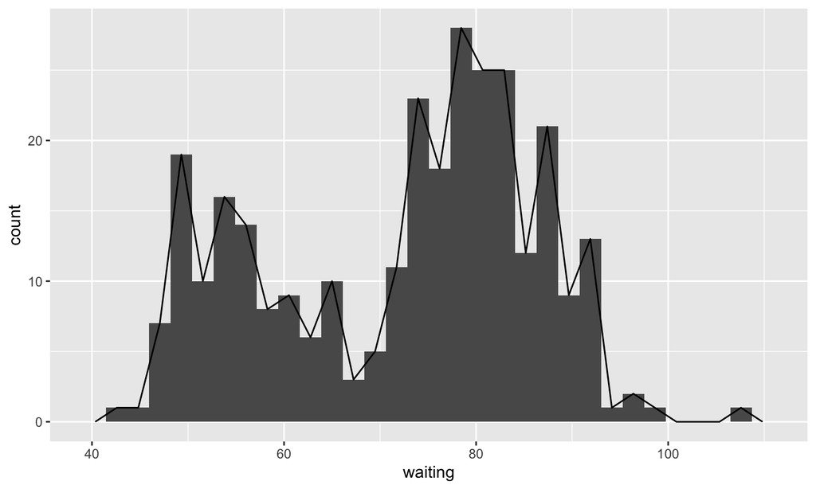

## 12.1.3 The Averaged Shifted Histogram (ASH)

- Binwidth is not the only consideration
- With a fixed binwidth, moving the class boundaries gives different estimators. (See Fig. 12.4).
- Scott proposes ASH to average density estimators while progressively shifted by \(h/m\).
- Normal assumption gives (12.9).

## Example 12.5, 12.6

- Calculations for ASH.
- Average the estimates from each histogram for each value.
- Clever formula (12.10), note that you must have \(m-1\) empty bins on the left and right.
- Follow Example 12.6 to complete Exercise 12.6 ASH density for old faithful.

## Closing / Ch. 12 Problem set

- Revisit HW.
- Questions?
- Students please summarize/ask questions about what we discussed today.